# Hurricanes NOLA: CAREER Project

Connor Whalen

2025-02-18

# Introduction

This file contains all code pertaining to the CAREER project in NOLA’s hurricane analysis.

# Setup

#### Load full datasets (parasites collected and NOAA SPI precipitation data) and prep data for analysis

# Hurricane analysis and data prepping

### Controls

Find the average date of a hurricane, so that we can identify when the average hurricane starts and stops and how long it lasts – this will be used to assign a period of time to our hurricane controls. [This code was used to identify these information, but no longer needs to be run for the analysis to work]. Then, pick out the years in which there was no hurricane, so that we can identify which years to assign as control in our hurricane analysis.

```r
average_hurr <- hurricane_df6 %>%
  filter(str_detect(ewe_type, "hurricane")) %>%
  mutate(
    month = month(date),
    day = day(date)
  ) %>%
  summarise(
    average_month = mean(month),
    average_day = mean(day)
  )
# average hurricane happens on 9/18 each year
# find average duration of hurricane event
# Define date ranges for hurricane events
hurricane_events <- data.frame(
  start_date = as.Date(c("1969-08-14", "1971-09-05", "1988-09-08",
                         "1992-08-16", "2004-09-02", "1964-09-28",
                         "1965-08-27", "1974-08-29", "1995-09-27",
                         "1998-09-15", "2002-09-21", "1985-08-28",
                         "2004-09-14", "1979-07-09", "1985-08-12",
                         "1985-10-26", "1988-09-07", "1997-07-16")),
  end_date = as.Date(c("1969-08-22", "1971-09-15", "1988-09-19",
                       "1992-08-19", "2004-09-25", "1964-10-05",
                       "1965-09-13", "1974-09-10", "1995-10-06",
                       "1998-10-01", "2002-10-04", "1985-09-04",
                       "2004-09-27", "1979-07-16", "1985-08-20",
                       "1985-11-03", "1988-09-11", "1997-07-27"))
)

# Calculate durations of each hurricane event
hurricane_events$duration <- as.numeric(hurricane_events$end_date - hurricane_events$start_date)
# Calculate the average duration
average_duration <- mean(hurricane_events$duration)
# Print result
average_duration
# average is 10 days
# years in which there was no hurricane: 1963, 1966, 1967, 1968, 1970, 1972, 1973, 1975, 1976, 1977, 1978, 1980, 1981, 1982, 1983, 1984, 1986, 1987, 1989, 1990, 1991, 1993, 1994, 1999, 2000, 2003
```

### Hurricane events

Add actual hurricane timeline parameters for 6 month (6 month meaning a buffer period of 6 months before a hurricane [denoted as pre] and 6 months after a hurricane [denoted post]). These dates for hurricane occurance are taken from the NOAA hurricane watch website and represent all hurricane events that crossed a 50 mile boundary of the Pearl River from source to sea.

```r
hurricane_df6 <- full_data %>%
  mutate(ewe_type = case_when(
    date >= as.Date("1969-02-14") & date <= as.Date("1969-08-14") ~ "pre_5",
    date >= as.Date("1969-08-14") & date <= as.Date("1969-08-22") ~ "hurricane_5", #camille
    date >= as.Date("1969-08-22") & date <= as.Date("1970-02-22") ~ "post_5",
    date >= as.Date("1971-03-05") & date <= as.Date("1971-09-05") ~ "pre_5",
    date >= as.Date("1971-09-05") & date <= as.Date("1971-09-15") ~ "hurricane_5", #edith
    date >= as.Date("1971-09-15") & date <= as.Date("1972-03-15") ~ "post_5",
    date >= as.Date("1992-02-16") & date <= as.Date("1992-08-16") ~ "pre_5",
    date >= as.Date("1992-08-16") & date <= as.Date("1992-08-19") ~ "hurricane_5", #andrew
    date >= as.Date("1992-08-19") & date <= as.Date("1993-03-19") ~ "post_5",
    date >= as.Date("2004-03-02") & date <= as.Date("2004-09-02") ~ "pre_5",
    date >= as.Date("2004-09-02") & date <= as.Date("2004-09-25") ~ "hurricane_5", #ivan -- external
    date >= as.Date("2004-09-25") & date <= as.Date("2005-03-25") ~ "post_5",
    date >= as.Date("1964-03-28") & date <= as.Date("1964-09-28") ~ "pre_4",
    date >= as.Date("1964-09-28") & date <= as.Date("1964-10-05") ~ "hurricane_4", #hilda
    date >= as.Date("1964-10-05") & date <= as.Date("1965-04-05") ~ "post_4",
    date >= as.Date("1965-02-27") & date <= as.Date("1965-08-27") ~ "pre_4",
    date >= as.Date("1965-08-27") & date <= as.Date("1965-09-13") ~ "hurricane_4", #betsy
    date >= as.Date("1965-09-13") & date <= as.Date("1966-03-13") ~ "post_4",
    date >= as.Date("1974-02-28") & date <= as.Date("1974-08-29") ~ "pre_4",
    date >= as.Date("1974-08-29") & date <= as.Date("1974-09-10") ~ "hurricane_4", #carmen -- external
    date >= as.Date("1974-09-10") & date <= as.Date("1975-03-10") ~ "post_4",
    date >= as.Date("1998-03-15") & date <= as.Date("1998-09-15") ~ "pre_4",
    date >= as.Date("1998-09-15") & date <= as.Date("1998-10-01") ~ "hurricane_4", #georges
    date >= as.Date("1998-10-01") & date <= as.Date("1999-04-01") ~ "post_4",
    date >= as.Date("2002-03-21") & date <= as.Date("2002-09-21") ~ "pre_4",
    date >= as.Date("2002-09-21") & date <= as.Date("2002-10-04") ~ "hurricane_4", #lili -- external
    date >= as.Date("2002-10-04") & date <= as.Date("2003-04-04") ~ "post_4",
    date >= as.Date("1985-02-28") & date <= as.Date("1985-08-28") ~ "pre_3",
    date >= as.Date("1985-08-28") & date <= as.Date("1985-09-04") ~ "hurricane_3", #elena
    date >= as.Date("1985-09-04") & date <= as.Date("1986-03-04") ~ "post_3",
    date >= as.Date("2002-03-14") & date <= as.Date("2002-09-14") ~ "pre_3",
    date >= as.Date("2002-09-14") & date <= as.Date("2002-09-27") ~ "hurricane_3", #isidore
    date >= as.Date("2002-09-27") & date <= as.Date("2003-03-27") ~ "post_3",
    date >= as.Date("1979-01-09") & date <= as.Date("1979-07-09") ~ "pre_1",
    date >= as.Date("1979-07-09") & date <= as.Date("1979-07-16") ~ "hurricane_1", #bob
    date >= as.Date("1979-07-16") & date <= as.Date("1980-01-16") ~ "post_1",
    date >= as.Date("1985-02-12") & date <= as.Date("1985-08-12") ~ "pre_1",
    date >= as.Date("1985-08-12") & date <= as.Date("1985-08-20") ~ "hurricane_1", #danny -- external
    date >= as.Date("1985-08-20") & date <= as.Date("1986-02-20") ~ "post_1",
    date >= as.Date("1985-04-26") & date <= as.Date("1985-10-26") ~ "pre_1",
    date >= as.Date("1985-10-26") & date <= as.Date("1985-11-03") ~ "hurricane_1", #juan
    date >= as.Date("1985-11-03") & date <= as.Date("1986-05-03") ~ "post_1",
    date >= as.Date("1988-03-07") & date <= as.Date("1988-09-07") ~ "pre_1",
    date >= as.Date("1988-09-07") & date <= as.Date("1988-09-11") ~ "hurricane_1", #florence
    date >= as.Date("1988-09-11") & date <= as.Date("1989-03-11") ~ "post_1",
    date >= as.Date("1997-01-16") & date <= as.Date("1997-07-16") ~ "pre_1",
    date >= as.Date("1997-07-16") & date <= as.Date("1997-07-27") ~ "hurricane_1", #danny
    date >= as.Date("1997-07-27") & date <= as.Date("1998-01-27") ~ "post_1",
    date >= as.Date("1988-02-07") & date <= as.Date("1988-08-07") ~ "pre_ts",
    date >= as.Date("1988-08-08") & date <= as.Date("1988-08-10") ~ "tropical_storm", #beryl
    date >= as.Date("1988-08-11") & date <= as.Date("1989-02-11") ~ "post_ts",
    date >= as.Date("1998-03-26") & date <= as.Date("1998-09-26") ~ "pre_ts",
    date >= as.Date("1998-09-27") & date <= as.Date("1998-09-30") ~ "tropical_storm", #hermine
    date >= as.Date("1998-10-01") & date <= as.Date("1999-04-01") ~ "post_ts",
    date >= as.Date("2000-12-05") & date <= as.Date("2001-06-05") ~ "pre_ts",
    date >= as.Date("2001-06-05") & date <= as.Date("2001-06-20") ~ "tropical_storm", #allison
    date >= as.Date("2001-06-20") & date <= as.Date("2001-12-20") ~ "post_ts",
    date >= as.Date("2002-02-04") & date <= as.Date("2002-08-04") ~ "pre_ts",
    date >= as.Date("2002-08-04") & date <= as.Date("2002-08-09") ~ "tropical_storm", #bertha
    date >= as.Date("2002-08-09") & date <= as.Date("2003-02-09") ~ "post_ts",
    date >= as.Date("2002-03-12") & date <= as.Date("2002-09-12") ~ "pre_ts",
    date >= as.Date("2002-09-12") & date <= as.Date("2002-09-15") ~ "tropical_storm", #hanna
    date >= as.Date("2002-09-15") & date <= as.Date("2003-03-15") ~ "post_ts",
    date >= as.Date("2002-12-27") & date <= as.Date("2003-06-27") ~ "pre_ts",
    date >= as.Date("2003-06-28") & date <= as.Date("2003-07-03") ~ "tropical_storm", #bill
    date >= as.Date("2003-07-04") & date <= as.Date("2004-01-04") ~ "post_ts",
    date >= as.Date("1965-03-23") & date <= as.Date("1965-09-23") ~ "pre_ts",
    date >= as.Date("1965-09-24") & date <= as.Date("1965-09-30") ~ "tropical_storm", #debbie
    date >= as.Date("1965-10-01") & date <= as.Date("1966-04-01") ~ "post_ts",
    date >= as.Date("1995-01-30") & date <= as.Date("1995-07-30") ~ "pre_double",
    date >= as.Date("1995-07-31") & date <= as.Date("1995-10-06") ~ "hurricane_double", #opal (4) and erin (2) combined
    date >= as.Date("1995-10-07") & date <= as.Date("1996-04-07") ~ "post_double",
    TRUE ~ "no event"
  ))
```

```r
# make a new column for storm intensity

hurricane_df6 <- hurricane_df6 %>%
  mutate(storm_intensity = case_when(
    str_detect(ewe_type, "1") ~ "one",
    str_detect(ewe_type, "2") ~ "two",
    str_detect(ewe_type, "3") ~ "three",
    str_detect(ewe_type, "4") ~ "four",
    str_detect(ewe_type, "5") ~ "five",
    str_detect(ewe_type, "ts") ~ "ts",
    str_detect(ewe_type, "double") ~ "double",
    TRUE ~ "no event"
  ))


# create hurricane control categories just like with the other dataset by assigning non-event years to have a pre and post category -- 6 months

hurricane_df6 <- hurricane_df6 %>%
  mutate(control = case_when(
    date >= as.Date("1963-03-18") & date <= as.Date("1963-09-18") ~ "pre_control",
    date >= as.Date("1963-09-18") & date <= as.Date("1963-09-28") ~ "control",
    date >= as.Date("1963-09-28") & date <= as.Date("1964-03-28") ~ "post_control",
    date >= as.Date("1966-03-18") & date <= as.Date("1966-09-18") ~ "pre_control",
    date >= as.Date("1966-09-18") & date <= as.Date("1966-09-28") ~ "control",
    date >= as.Date("1966-09-28") & date <= as.Date("1967-03-28") ~ "post_control",
    date >= as.Date("1967-03-18") & date <= as.Date("1967-09-18") ~ "pre_control",
    date >= as.Date("1967-09-18") & date <= as.Date("1967-09-28") ~ "control",
    date >= as.Date("1967-09-28") & date <= as.Date("1968-03-28") ~ "post_control",
    date >= as.Date("1968-03-18") & date <= as.Date("1968-09-18") ~ "pre_control",
    date >= as.Date("1968-09-18") & date <= as.Date("1968-09-28") ~ "control",
    date >= as.Date("1968-09-28") & date <= as.Date("1969-03-28") ~ "post_control",
    date >= as.Date("1970-03-18") & date <= as.Date("1970-09-18") ~ "pre_control",
    date >= as.Date("1970-09-18") & date <= as.Date("1970-09-28") ~ "control",
    date >= as.Date("1970-09-28") & date <= as.Date("1971-03-28") ~ "post_control",
    date >= as.Date("1972-03-18") & date <= as.Date("1972-09-18") ~ "pre_control",
    date >= as.Date("1972-09-18") & date <= as.Date("1972-09-28") ~ "control",
    date >= as.Date("1972-09-28") & date <= as.Date("1973-03-28") ~ "post_control",
    date >= as.Date("1973-03-18") & date <= as.Date("1973-09-18") ~ "pre_control",
    date >= as.Date("1973-09-18") & date <= as.Date("1973-09-28") ~ "control",
    date >= as.Date("1973-09-28") & date <= as.Date("1974-03-28") ~ "post_control",
    date >= as.Date("1975-03-18") & date <= as.Date("1975-09-18") ~ "pre_control",
    date >= as.Date("1975-09-18") & date <= as.Date("1975-09-28") ~ "control",
    date >= as.Date("1975-09-28") & date <= as.Date("1976-03-28") ~ "post_control",
    date >= as.Date("1976-03-18") & date <= as.Date("1976-09-18") ~ "pre_control",
    date >= as.Date("1976-09-18") & date <= as.Date("1976-09-28") ~ "control",
    date >= as.Date("1976-09-28") & date <= as.Date("1977-03-28") ~ "post_control",
    date >= as.Date("1977-03-18") & date <= as.Date("1977-09-18") ~ "pre_control",
    date >= as.Date("1977-09-18") & date <= as.Date("1977-09-28") ~ "control",
    date >= as.Date("1977-09-28") & date <= as.Date("1978-03-28") ~ "post_control",
    date >= as.Date("1978-03-18") & date <= as.Date("1978-09-18") ~ "pre_control",
    date >= as.Date("1978-09-18") & date <= as.Date("1978-09-28") ~ "control",
    date >= as.Date("1978-09-28") & date <= as.Date("1979-03-28") ~ "post_control",
    date >= as.Date("1980-03-18") & date <= as.Date("1980-09-18") ~ "pre_control",
    date >= as.Date("1980-09-18") & date <= as.Date("1980-09-28") ~ "control",
    date >= as.Date("1980-09-28") & date <= as.Date("1981-03-28") ~ "post_control",
    date >= as.Date("1981-03-18") & date <= as.Date("1981-09-18") ~ "pre_control",
    date >= as.Date("1981-09-18") & date <= as.Date("1981-09-28") ~ "control",
    date >= as.Date("1981-09-28") & date <= as.Date("1982-03-28") ~ "post_control",
    date >= as.Date("1982-03-18") & date <= as.Date("1982-09-18") ~ "pre_control",
    date >= as.Date("1982-09-18") & date <= as.Date("1982-09-28") ~ "control",
    date >= as.Date("1982-09-28") & date <= as.Date("1983-03-28") ~ "post_control",
    date >= as.Date("1983-03-18") & date <= as.Date("1983-09-18") ~ "pre_control",
    date >= as.Date("1983-09-18") & date <= as.Date("1983-09-28") ~ "control",
    date >= as.Date("1983-09-28") & date <= as.Date("1984-03-28") ~ "post_control",
    date >= as.Date("1987-03-18") & date <= as.Date("1987-09-18") ~ "pre_control",
    date >= as.Date("1987-09-18") & date <= as.Date("1987-09-28") ~ "control",
    date >= as.Date("1987-09-28") & date <= as.Date("1988-03-28") ~ "post_control",
    date >= as.Date("1989-03-18") & date <= as.Date("1989-09-18") ~ "pre_control",
    date >= as.Date("1989-09-18") & date <= as.Date("1989-09-28") ~ "control",
    date >= as.Date("1989-09-28") & date <= as.Date("1990-03-28") ~ "post_control",
    date >= as.Date("1990-03-18") & date <= as.Date("1990-09-18") ~ "pre_control",
    date >= as.Date("1990-09-18") & date <= as.Date("1990-09-28") ~ "control",
    date >= as.Date("1990-09-28") & date <= as.Date("1991-03-28") ~ "post_control",
    date >= as.Date("1991-03-18") & date <= as.Date("1991-09-18") ~ "pre_control",
    date >= as.Date("1991-09-18") & date <= as.Date("1991-09-28") ~ "control",
    date >= as.Date("1991-09-28") & date <= as.Date("1992-03-28") ~ "post_control",
    date >= as.Date("1999-03-18") & date <= as.Date("1999-09-18") ~ "pre_control",
    date >= as.Date("1999-09-18") & date <= as.Date("1999-09-28") ~ "control",
    date >= as.Date("1999-09-28") & date <= as.Date("2000-03-28") ~ "post_control",
    date >= as.Date("2000-03-18") & date <= as.Date("2000-09-18") ~ "pre_control",
    date >= as.Date("2000-09-18") & date <= as.Date("2000-09-28") ~ "control",
    date >= as.Date("2000-09-28") & date <= as.Date("2001-03-28") ~ "post_control",
    date >= as.Date("2003-03-18") & date <= as.Date("2003-09-18") ~ "pre_control",
    date >= as.Date("2003-09-18") & date <= as.Date("2003-09-28") ~ "control",
    date >= as.Date("2003-09-28") & date <= as.Date("2004-03-28") ~ "post_control",
    TRUE ~ "no event"
  ))
```

```r
hurricane_df6 <- hurricane_df6 %>%
  mutate(event = case_when(
    ewe_type == "pre_5" ~ "hurricane",
    ewe_type == "post_5" ~ "hurricane",
    ewe_type == "pre_4" ~ "hurricane",
    ewe_type == "post_4" ~ "hurricane",
    ewe_type == "pre_3" ~ "hurricane",
    ewe_type == "post_3" ~ "hurricane",
    ewe_type == "pre_2" ~ "hurricane",
    ewe_type == "post_2" ~ "hurricane",
    ewe_type == "pre_1" ~ "hurricane",
    ewe_type == "post_1" ~ "hurricane",
    ewe_type == "pre_ts" ~ "hurricane",
    ewe_type == "post_ts" ~ "hurricane",
    ewe_type == "pre_double" ~ "hurricane",
    ewe_type == "post_double" ~ "hurricane",
    ewe_type == "no event" & control == "pre_control" ~ "control",
    ewe_type == "no event" & control == "post_control" ~ "control",
    TRUE ~ "NA"
  )) %>%
  filter(event != "NA")

hurricane_df6 <- hurricane_df6 %>%
  mutate(timing = case_when(
    ewe_type == "pre_5" ~ "pre",
    ewe_type == "post_5" ~ "post",
    ewe_type == "pre_4" ~ "pre",
    ewe_type == "post_4" ~ "post",
    ewe_type == "pre_3" ~ "pre",
    ewe_type == "post_3" ~ "post",
    ewe_type == "pre_2" ~ "pre",
    ewe_type == "post_2" ~ "post",
    ewe_type == "pre_1" ~ "pre",
    ewe_type == "post_1" ~ "post",
    ewe_type == "pre_ts" ~ "pre",
    ewe_type == "post_ts" ~ "post",
    ewe_type == "pre_double" ~ "pre",
    ewe_type == "post_double" ~ "post",
    control == "pre_control" ~ "pre",
    control == "post_control" ~ "post",
    ewe_type == "hurricane_4" ~ "during",
    TRUE ~ "NA"
  )) %>%
  filter(timing != "NA")


hurricane_df6 <- hurricane_df6 %>%
  mutate(timing = factor(timing, levels = c("pre", "post"))) %>%
  mutate(timing = relevel(timing, ref = "pre")) #%>%
 # mutate(event = factor(event, levels = c("hurricane", "control"))) %>%
 # mutate(event = relevel(event, ref = "control"))

ewe_table6 <- table(hurricane_df6$event)
# view(ewe_table6)
ewe_table6_2 <- table(hurricane_df6$timing)
# view(ewe_table6_2)
```

Visualization and checking of data frame.

```r
head(hurricane_df6)
```

```
##   x x1            fish_psite_combo catalog_number year_collected
## 1 1  1 Carpiodes velifer_CEST.ARCH         178358           1996
## 2 2  2 Carpiodes velifer_CEST.ARCH          31000           1963
## 3 3  3 Carpiodes velifer_CEST.ARCH          31000           1963
## 4 4  4 Carpiodes velifer_CEST.ARCH          31000           1963
## 5 5  5 Carpiodes velifer_CEST.ARCH          31000           1963
## 6 6  6 Carpiodes velifer_CEST.ARCH          31000           1963
##   month_collected day_collected individual_fish_id dissector_and_examiner
## 1               4             6          178358_02         JT DMDM KL GMC
## 2              12            12           31000_02             ij djb cjw
## 3              12            12           31000_06               DJB DMDM
## 4              12            12           31000_04                 djb kl
## 5              12            12           31000_03               djb dmdm
## 6              12            12           31000_05                jt dmdm
##   dissection_date sex total_length_mm standard_length_mm weight_mg      ci
```

[output cut: 55 more lines]

```r
hurricane_df_filtered <- hurricane_df6 %>%
  filter(psite_type %in% c("trematode", "trematode_metacercaria", "monogenean", "cilliate", "nematode", "acanthocephalan", "cestode"))


summary_data <- hurricane_df6 %>%
  group_by(psite_type, event, timing) %>%
  summarise(total_abundance = sum(psite_abundance, na.rm = TRUE), .groups = 'drop')

print(summary_data)
```

```
## # A tibble: 44 × 4
##    psite_type      event     timing total_abundance
##    <chr>           <chr>     <fct>            <int>
##  1 acanthocephalan control   pre                  3
##  2 acanthocephalan control   post                13
##  3 acanthocephalan hurricane pre                  6
##  4 acanthocephalan hurricane post                15
##  5 cestode         control   pre                 17
##  6 cestode         control   post                35
##  7 cestode         hurricane pre                 36
##  8 cestode         hurricane post                 8
##  9 ciliate         control   pre                  0
## 10 ciliate         control   post               200
## # ℹ 34 more rows
```

```r
# remove specific datapoints with low replication
hurricane_df_filtered <- hurricane_df6 %>%
  filter(!(psite_type %in% c("cilliate", "leech", "myxozoan", "nematomorph") &
           event %in% c("control", "hurricane") &
           timing %in% c("pre", "post")))
## ^ this did not work

summary_data <- hurricane_df_filtered %>%
  group_by(psite_type, event, timing) %>%
  summarise(total_abundance = sum(psite_abundance, na.rm = TRUE), .groups = 'drop')

print(summary_data)
```

```
## # A tibble: 32 × 4
##    psite_type      event     timing total_abundance
##    <chr>           <chr>     <fct>            <int>
##  1 acanthocephalan control   pre                  3
##  2 acanthocephalan control   post                13
##  3 acanthocephalan hurricane pre                  6
##  4 acanthocephalan hurricane post                15
##  5 cestode         control   pre                 17
##  6 cestode         control   post                35
##  7 cestode         hurricane pre                 36
##  8 cestode         hurricane post                 8
##  9 ciliate         control   pre                  0
## 10 ciliate         control   post               200
## # ℹ 22 more rows
```

# Plots

Create color palette and assign faceting labels

# Models

## Hurricane count (abundance)

```r
summary(hurricane_count <- glmmTMB(psite_abundance ~ event*timing*psite_type + (total_length_mm|fish_sp_x/parasite_taxonomic_group) + (1|ci/catalog_number) + (1|storm_intensity) + (1|year_collected/season) + (1|fish_sp_y/psite_spp_y),
                          data = hurricane_df_filtered, family = truncated_nbinom1, ziformula = ~ 1))
```

```
##  Family: truncated_nbinom1  ( log )
## Formula:
## psite_abundance ~ event * timing * psite_type + (total_length_mm |
##     fish_sp_x/parasite_taxonomic_group) + (1 | ci/catalog_number) +
##     (1 | storm_intensity) + (1 | year_collected/season) + (1 |
##     fish_sp_y/psite_spp_y)
## Zero inflation:                   ~1
## Data: hurricane_df_filtered
##
##      AIC      BIC   logLik deviance df.resid
##       NA       NA       NA       NA    21598
##
## Random effects:
##
## Conditional model:
##  Groups                             Name            Variance Std.Dev. Corr
##  parasite_taxonomic_group:fish_sp_x (Intercept)     1.0377   1.0187
##                                     total_length_mm 0.5976   0.7730   0.13
##  fish_sp_x                          (Intercept)     0.8447   0.9191
##                                     total_length_mm 0.9383   0.9687   -0.12
##  catalog_number:ci                  (Intercept)     0.2503   0.5003
##  ci                                 (Intercept)     0.9881   0.9940
##  storm_intensity                    (Intercept)     0.8472   0.9204
##  season:year_collected              (Intercept)     0.5494   0.7412
##  year_collected                     (Intercept)     0.6893   0.8302
##  psite_spp_y:fish_sp_y              (Intercept)     0.9807   0.9903
##  fish_sp_y                          (Intercept)     0.8359   0.9143
## Number of obs: 21645, groups:
## parasite_taxonomic_group:fish_sp_x, 37; fish_sp_x, 7; catalog_number:ci, 308; ci, 2; storm_intensity, 7; season:year_collected, 114; year_collected, 40; psite_spp_y:fish_sp_y, 146; fish_sp_y, 7
##
## Dispersion parameter for truncated_nbinom1 family (): 25.4
##
## Conditional model:
##                                                              Estimate
## (Intercept)                                                 4.244e-02
## eventhurricane                                              2.388e-02
## timingpost                                                  9.514e-02
## psite_typecestode                                          -6.732e-03
## psite_typeciliate                                           9.680e-04
## psite_typecopepod                                          -9.484e-03
```

[output cut: 81 more lines]

```
## timingpost:psite_typemonogenean                                 NaN
## timingpost:psite_typenematode                                   NaN
## timingpost:psite_typetrematode                                  NaN
## timingpost:psite_typetrematode_metacercaria                     NaN
## eventhurricane:timingpost:psite_typecestode                     NaN
## eventhurricane:timingpost:psite_typeciliate                     NaN
## eventhurricane:timingpost:psite_typecopepod                     NaN
## eventhurricane:timingpost:psite_typemonogenean                  NaN
## eventhurricane:timingpost:psite_typenematode                    NaN
## eventhurricane:timingpost:psite_typetrematode                   NaN
## eventhurricane:timingpost:psite_typetrematode_metacercaria      NaN
##
## Zero-inflation model:
##             Estimate Std. Error z value Pr(>|z|)
## (Intercept)    2.784        NaN     NaN      NaN
```

Create diagnostics.

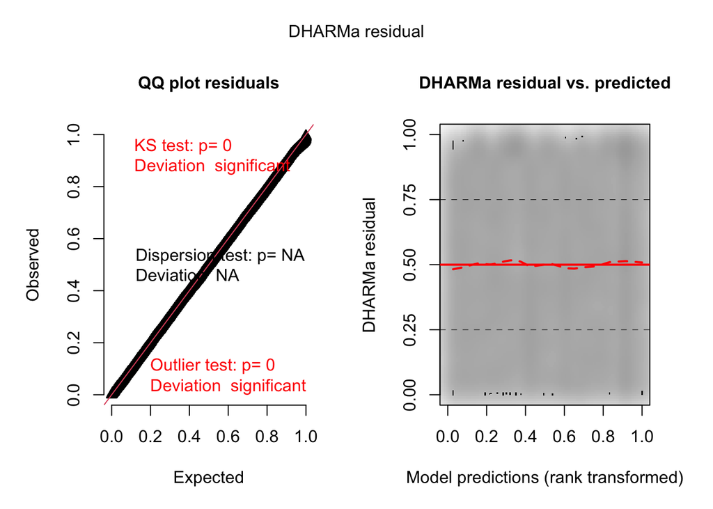

```r
# diagnostics
#Evaluate residuals
s = simulateResiduals(fittedModel = hurricane_count, n = 250)
plot(s)
```

```r
# other possible diagnostics
#df <- ggpredict(model, terms = "column[n=100]")
#plot(df)
#plot(df, show_data=TRUE)
```

## Hurricane prevalence (presence/absence for myxozoans) [not currently working]